# Healthcare Admissions & Cost Analysis Dashboard

Maykol Hernandez

2026-01-04

## Project Overview

The objective of this project was to design an interactive healthcare analytics dashboard that explores patient admissions, demographics, medical conditions, and billing patterns.

The project emphasizes end-to-end analytical thinking, from data preparation and modeling to insight-driven visualization design. Although the final dashboard was built in Power BI, this document outlines the analytical workflow, business reasoning, and technical decisions involved.

**Tools Used** - Power BI - DAX - Power Query - R Markdown (documentation)

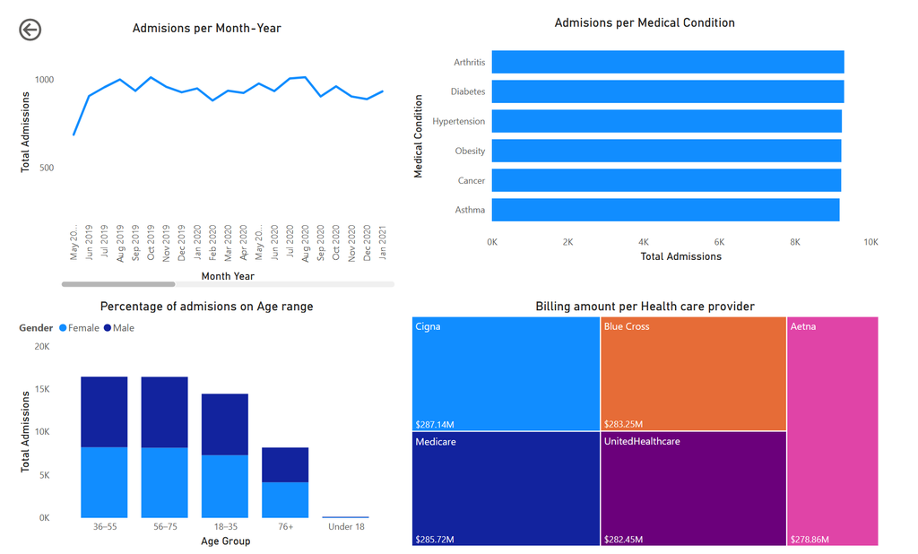

## Dataset Description

Key attributes include: - Patient demographics (age, gender, blood type) - Medical conditions and test results - Admission and discharge dates - Insurance providers - Billing amounts - Admission types (e.g., emergency, elective)

## Data Preparation & Modeling

### Data Cleaning (Power Query)

- Corrected data types for dates, numeric values, and currency fields
- Created a Length of Stay variable using admission and discharge dates
- Validated values to ensure realistic hospital stay durations

### Date Table Creation

A dedicated Date Table was created to enable proper time-based analysis.

```r
DateTable <- seq(
  from = as.Date("min(Date of Admission)"),
  to   = as.Date("max(Date of Admission)"),
  by   = "day"
)
```

## Measures & Calculations

```r
Total Admissions = COUNTROWS(healthcare_dataset)
Avg Length of Stay = AVERAGE(healthcare_dataset[Length of Stay])
Total Billing Amount = SUM(healthcare_dataset[Billing Amount])
Avg Billing per Admission = DIVIDE([Total Billing Amount], [Total Admissions])
```

## Visual Analysis & Insights

### Admissions Over Time

A line chart was used to analyze trends in hospital admissions by Month–Year.

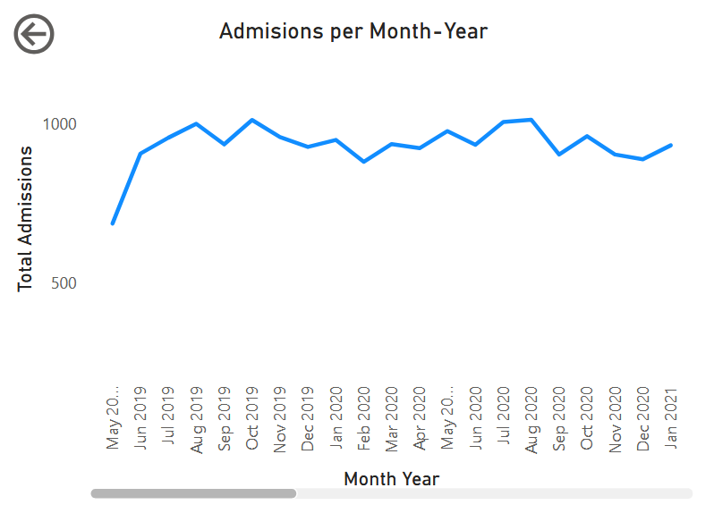

### Top Medical Conditions

A ranked bar chart highlighted conditions driving the highest admission volume.

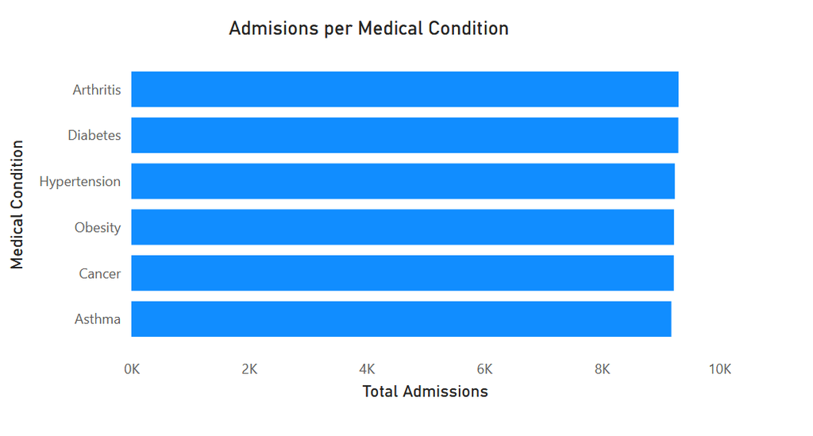

### Admissions by Age Group & Gender

A stacked column chart revealed demographic patterns.

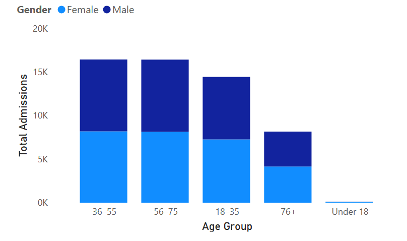

### Billing Distribution by Insurance Provider

A treemap displayed proportional contribution to total billing.

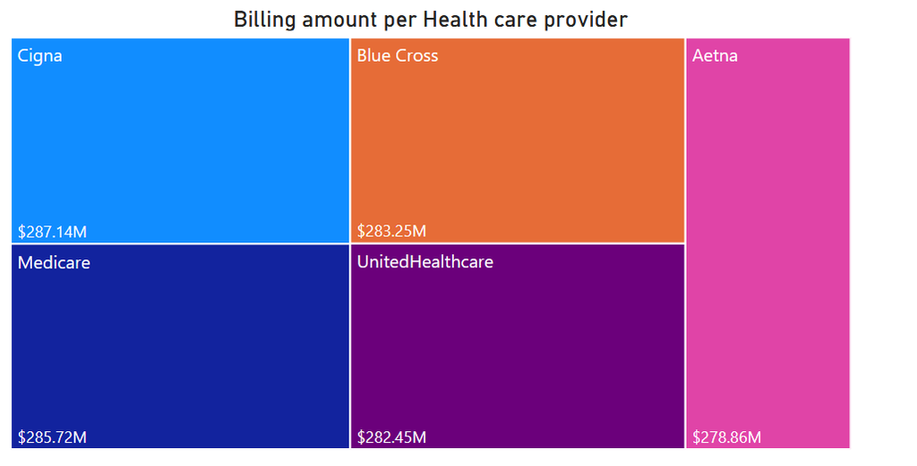